# Statistical Inference Project

# Part 1: Simulation Exercise

## Overview

This part of the report explores distributions of a large number of random samples from the exponential distribution. The exponential distribution has a mean of 1/lambda where lambda is the rate of growth for the exponential function. The mean and variation of the samples will be compared to the population or theoretical mean and variation.

## Simulations

To begin with, a value of 0.2 is assigned as the rate for the exponential function. A sampling of 40 observations is repeated 1000 times and subsequently organized into a 1000x40 matrix for ease of processing. Row-wise calculation of the mean for each 40 observation sampling is completed and then passed to the analysis in the next section of this report.

## Distribution of Random Sample Distributions

### Sample Mean vs Theoretical Mean

The frequency of means is plotted.

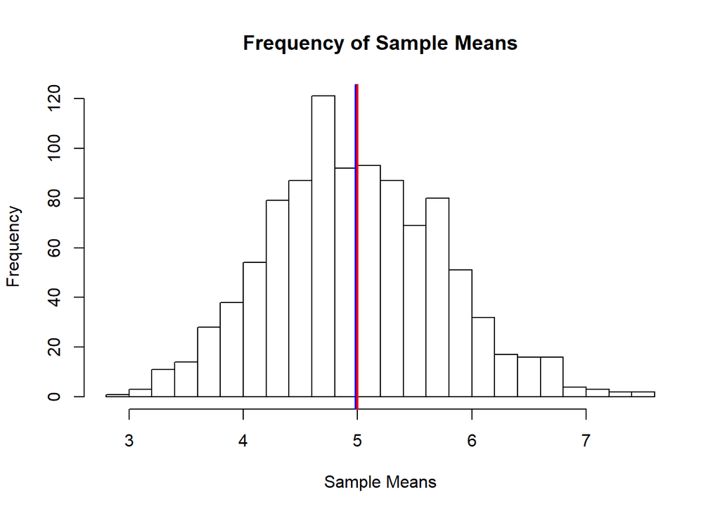

The distribution is nearly Gaussian in accord with the Central Limit Theorem. Also, the theoretical mean (mu=5) is nearly identical to the sample mean (mean=4.983) which is as expected since although the sample distribution has its own distribution it is centered at mu the population mean.

### Sample Variance vs Theoretical Variance

First the standard deviation for each 40 observation sample is calculated and collectively assigned to a variable.

Just as with the sample mean, the frequencies of the sample variations as measured by standard deviation is plotted. The mean of the sample standard deviations (blue) and the population standard deviation (red) are also plotted as vertical lines.

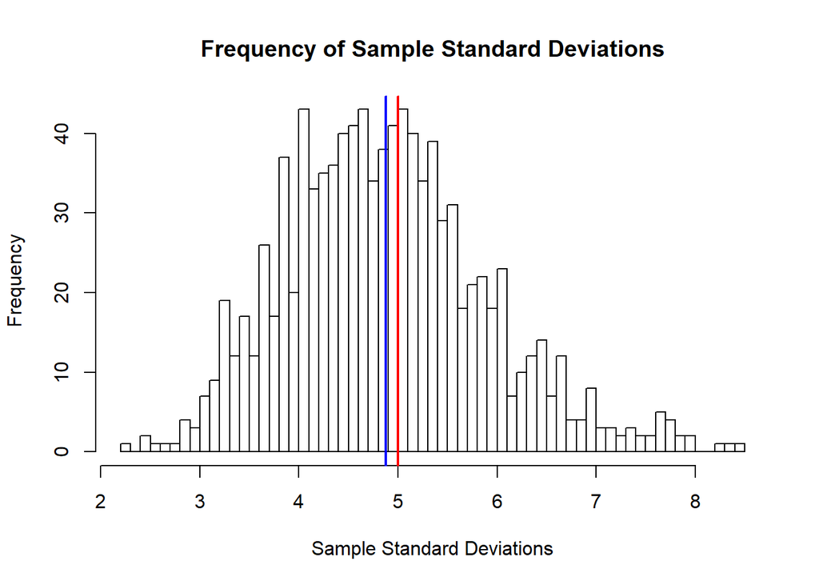

In the case of sample variation, the distribution is near Gaussian despite a slight right skew. The mean of the sample standard deviations (s=5) is very close as an estimate to the population or theoretical standard deviation (sigma=5). This makes sense since we know that the distribution of the sample variance (in this case standard deviation) is centered on the parameter that is is estimating (i.e. the population variation).

## Distribution

Next, we’ll show that the two distributions that we found, one for the sample means and the other for the sample variations, are both near normal in their distributions.

First we’ll scale each of the vectors to be standard normal.

Then we’ll plot them along with a density plot for the standard normal distribution.

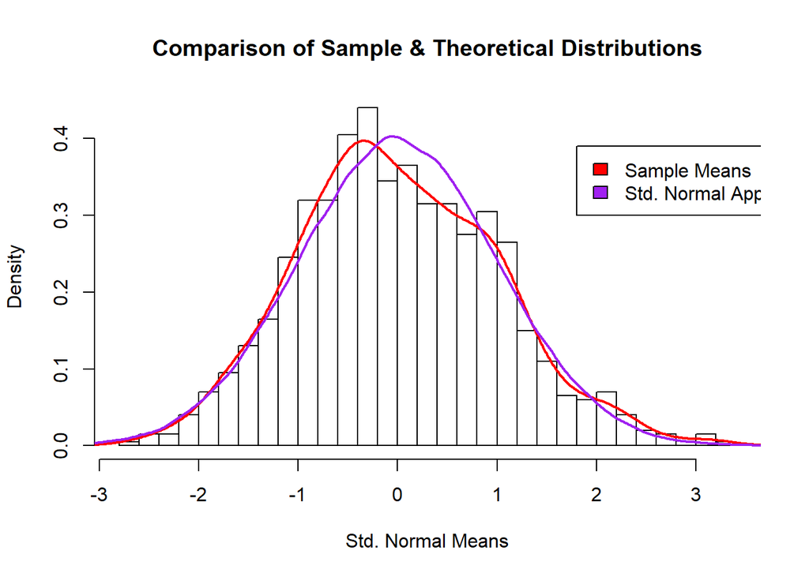

The distribution of sample means is a bit right-skewed but is nearly normal.

Let’s also check the distribution of sample variation means.

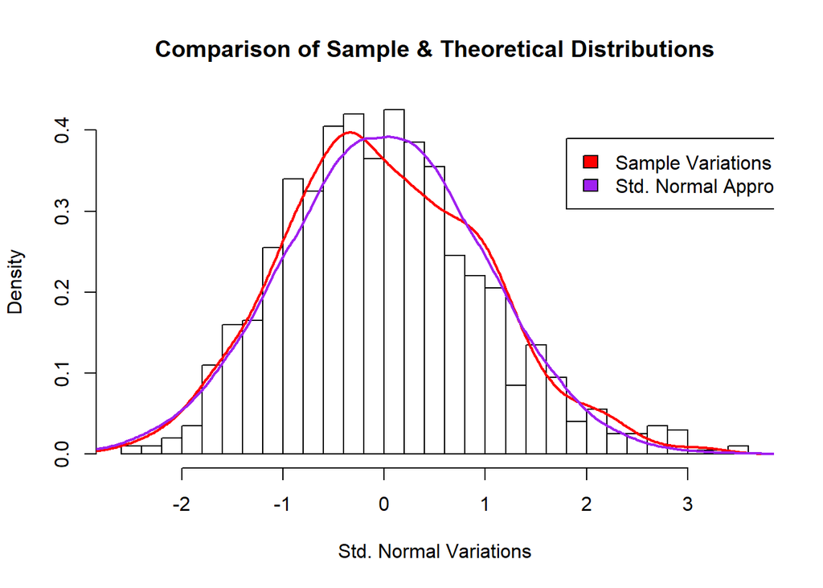

As with the distribution of sample means, this distribution also proves very close to normal despite some outliers that show some leverage over the density curve.

# Part 2: Basic Inferential Data Analysis

## Overview

In this section of the report, hypothesis testing is conducted using a toy dataset (ToothGrowth) from the datasets package.

## Basic Data Summary

The dataset contains the length of odontoblasts (cells responsible for tooth growth) in 60 guinea pigs. Each animal received one of three dosages of vitamin C (0.5, 1, 2 mg/day) by one of two delivery methods, orange juice or ascorbic acid. The animals were evenly distributed across the six groups created by the intersection of the variables `supplement` and `dose`.

The data read into a tibble object with dimension 60 by 3 for analysis.

A scatterplot of tooth length by observation index is plotted. The variables of `supplement` and `dose` are coded using color and shape respectively.

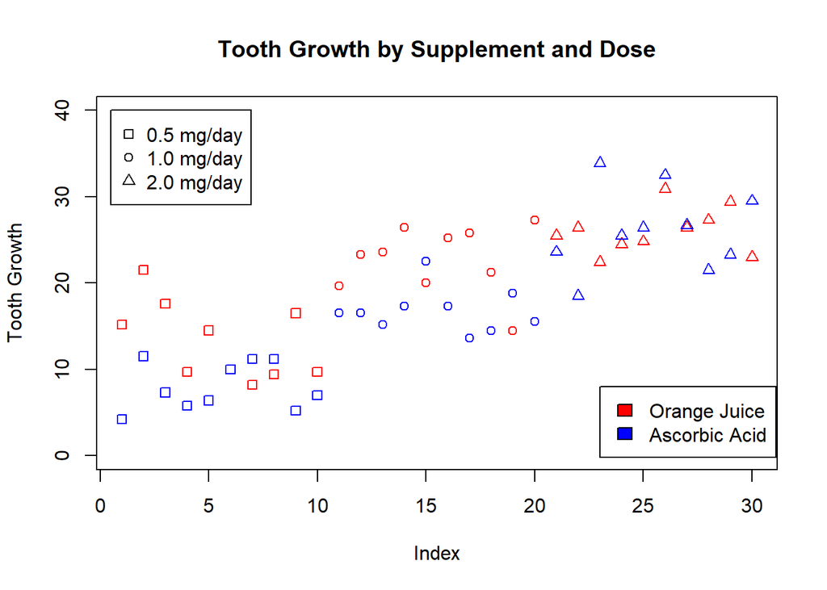

The plot shows a clear relationship between `dose` and tooth length. Any relationship between `supplement` and tooth length is not as clear. To explore that relationship further a boxplot is created.

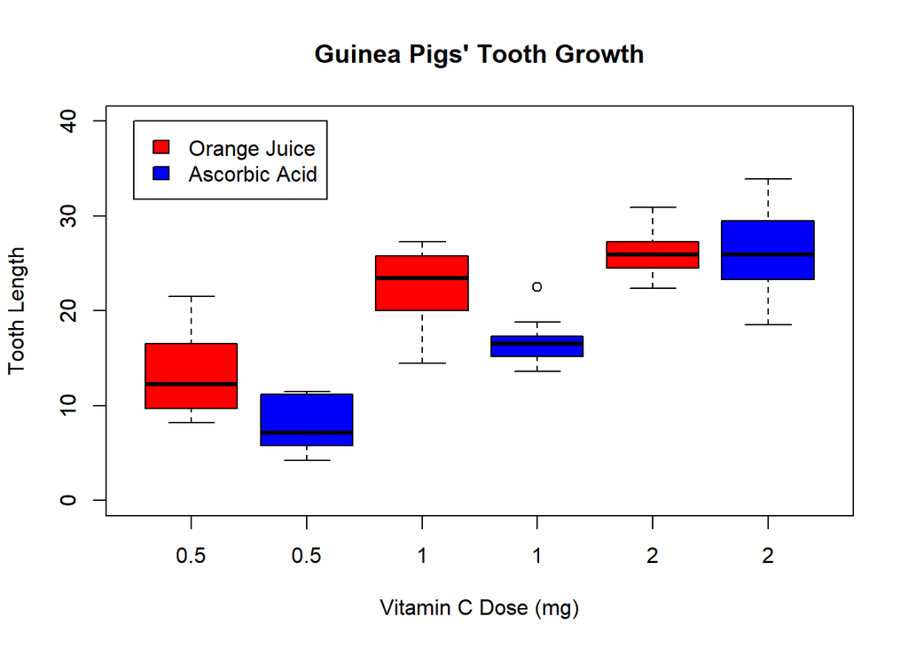

Here again, the positive relationship between `dose` and tooth length is evident. The boxplot also helps to clarify the relationship between the categorical variable `supplement` and tooth length. For all dose levels except 2.0 mg/day, there appears to be significant difference between tooth length related to orange juice compared to that related to ascorbic acid. In the case of the exception, the 2.0 mg/day dose, the means appear to be nearly identical.

We’ll next test the differences in means using t-tests.

## Inferential Testing

To start, a test is performed to look for a significant difference in mean tooth length by supplement without controlling for dose. Since the subjects for each subgroup are unique, that is the study is not paired, we’ll set the `paired` parameter to `FALSE`. Also, because the variations of the two subsets are unequal ($s^2_{oj}$ = 43.6334368, $s^2_{aa}$ = 68.3272299), the parameter `var.equal` is set to `FALSE`

```r
# t-test for difference in means
overall_test <- t.test(vd_all$len, oj_all$len, paired = FALSE)
```

The p-value for the difference in overall means (p = 0.0606345) is very close to the commonly accepted alpha value for significance 0.05. At the same time, the corresponding confidence interval of 95% includes zero (lower bound = -7.571, upper bound = 0.171), but only barely. This is at once reason to not reject $H_0$ and cause for further investigation since the borderline statistics and the exploratory plots suggest that controlling for dosage might yield significant differences.

So next we’ll perform t-tests on the difference in means of the two supplements this time controlling for dose. Since none of the tests are paired and because the variations for all dose groups compared by supplement are different, we’ll keep the parameters `paired` and `var.equal` as both `FALSE`.

```r
# t-test for difference in means by dose
dose_0.5 <- t.test(oj_all[oj_all$dose==0.5,]$len, vd_all[vd_all$dose==0.5,]$len,
                   paired = FALSE)

dose_1.0 <- t.test(oj_all[oj_all$dose==1,]$len, vd_all[vd_all$dose==1,]$len,
                   paired = FALSE)

dose_2.0 <- t.test(oj_all[oj_all$dose==2,]$len, vd_all[vd_all$dose==2,]$len,
                   paired = FALSE)
```

## Citations

Formatting for the boxplot was largely inspired by code by Roger Bivand as shown in the documentation for the boxplot() function.

Information about the dataset was copied from its documentation at help(ToothGrowth).